# Import fish and manipulate data a bit

## By site and zone

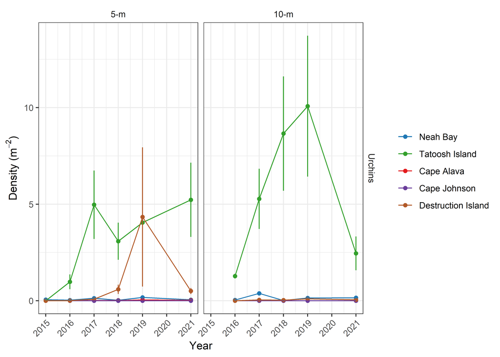

## By year and zone summarized across sites

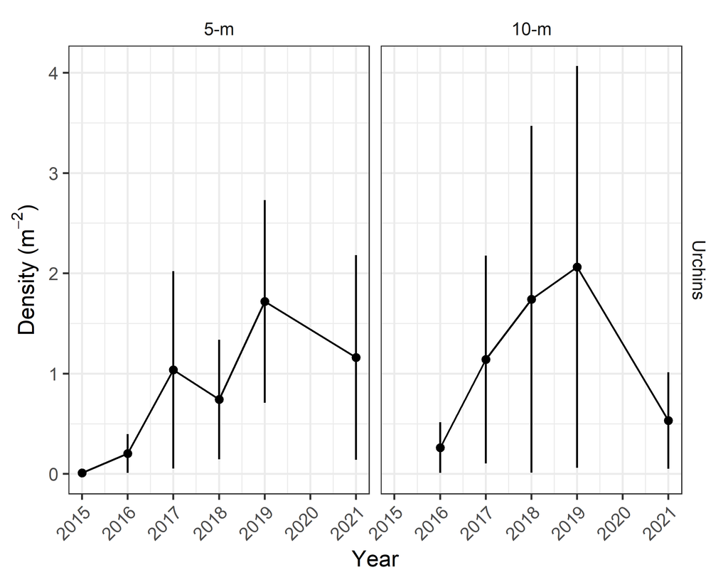

## Summarized across sites; 5 m and 10 m depths combined

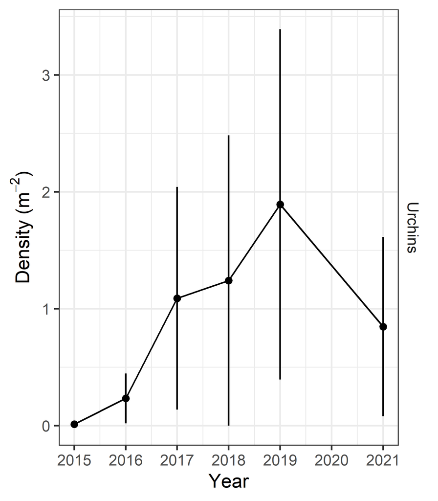

## Summarized across sites; 5-m depth zone only

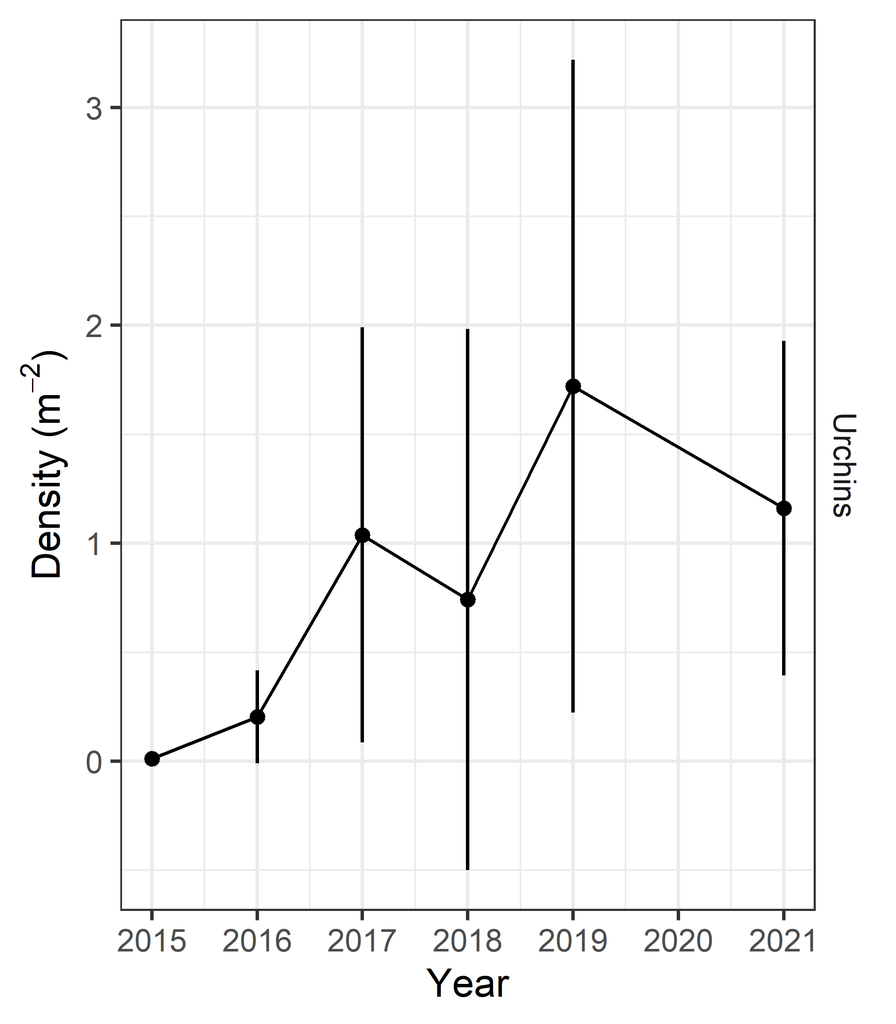

# Output data for multivariate statistics

## Combine kelp, fish, and inverts for capscale analysis

Not yet transformed to wide format in order to retain SD & SE info upon saving out. Transform in the Multiariate analysis rmd.

Output data files to use for multivariate ordinations.

Use these files and not raw files. Kelp and invert data have been converted to density to account for different transect lengths etc.

Quick view of what species to include in kelp ordinations. Basically only the big three have any abundance.

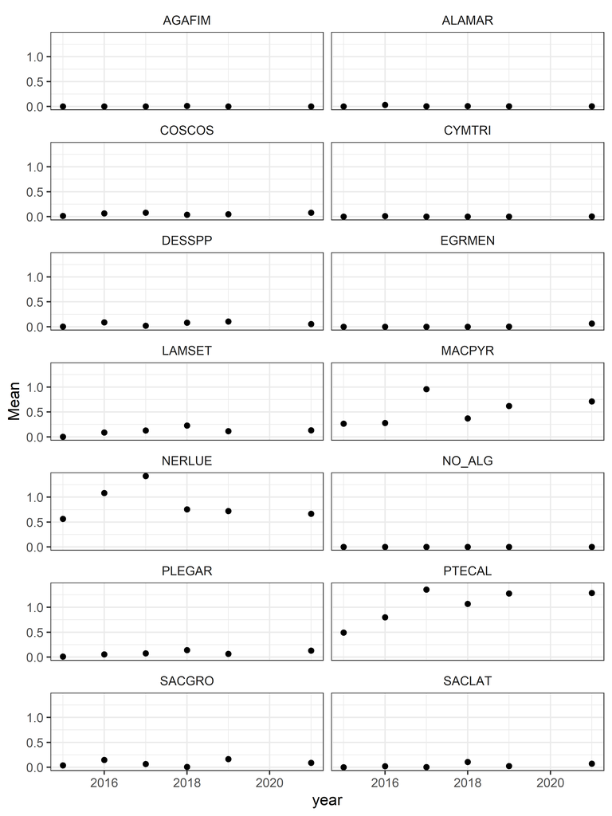

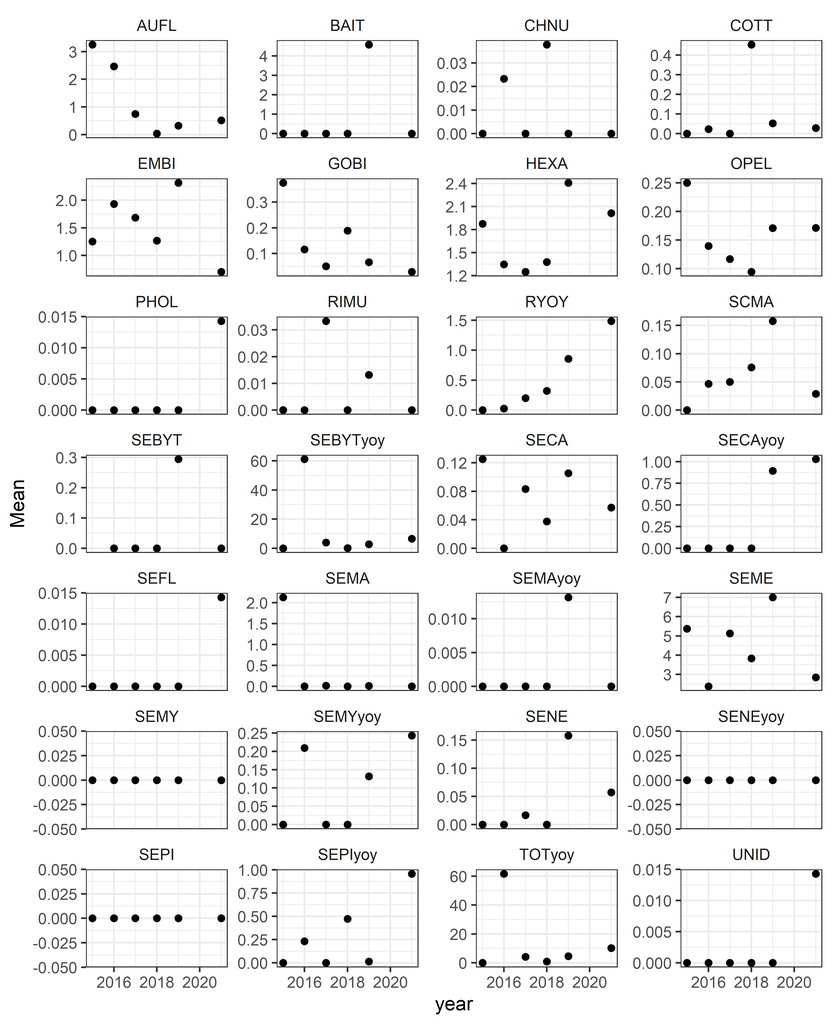

### NOTES

for multivariate analysis; cut and paste to that file

fish.spp = c(“OPEL”, “HEXA”, “SECA”, “SCMA” ,“SENE”, “SEME”, ‘EMBI’,‘GOBI’)

yoy.spp = c(“SECAyoy”, “SEPIyoy”, “SEMYyoy”, “SEBYTyoy”,“RYOY”)